# Practica 2

Jonathan Rodriguez

5 de enero de 2019

## Practica 2

### Enunciado

En esta práctica se elabora un caso práctico orientado a aprender a identificar los datos relevantes para un proyecto analítico y usar las herramientas de integración, limpieza, validación y análisis de las mismas. El objetivo de esta actividad será el tratamiento de un dataset, que puede ser el creado en la práctica 1 o bien cualquier dataset libre disponible en Kaggle. Siguiendo las principales etapas de un proyecto analítico, realizar las diferentes tareas y justificar.

### Descripción del dataset. ¿Por qué es importante y qué pregunta/problema pretende responder?

El conjunto de datos seleccionado se han obtenido desde https://www.kaggle.com/aashishjhamtani/automobile-insurancerecoge. Se compone de 40 variables de las cuales se ha descartado una al no contener ningún dato. Se pasan a describir las demás variables de las cuales se descartaran las que no sean objeto de estudio.

```
   columna      -         Descripción
```

- months_as_customer-> almacena los meses como cliente
- age -> almacena la edad del cliente
- policy_number -> almacena numero de poliza
- policy_bind_date -> almacena fecha formalización
- insured_zip -> almacena codigo postal
- insured_sex -> almacena sexo cliente
- insured_education_level-> almacena nivel educacion cliente
- insured_occupation -> almacena ocupacion cliente
- insured_relationship-> almacena relación cliente
- incident_date -> almacena fecha incidente
- incident_type -> almacena tipo de incidente
- collision_type -> almacena tipo de incidente
- incident_severity -> almacena tipo de severidad
- incident_state -> almacena estado donde se produjo
- incident_city -> almacena la ciudad incidente
- incident_hour_of_the_day -> almacena la hora incidente
- number_of_vehicles_involved-> almacena vehiculos implicados
- total_claim_amount -> almacena cantidada economica total
- auto_make -> almacena fabricante vehiculo
- auto_model -> almacena modelo vehiculo
- auto_year -> almacena año vehiculo
- fraud_reported -> almacena si se ha reportado como fraude

Contiene 1000 registros que recogen las reclamaciones realizadas a seguros, perfil del demandante, tipo de vehículos, resultado de la demanda, costes, si ha sido declarado como fraude y demás datos que nos sirven para dar respuesta a distintos tipos de pregunta o problemas.

Pregunta que podemos resolver con este análisis son:

- Obtener un tipo de perfil de usuario para saber cúal es el que más demanda o defrauda, así ponemos un plus en la contratación del seguro o descuento en caso contrario.
- Si existe una relación entre tipo de accidente y los declarados como fraudes. Con esto podemos clasificar si es problable que un tipo de colisión pueda ser fraulenta y marcarla como revisable por un agente de seguros.
- Análisis de tipos de vehículos con más colisiones, estados, etc. Determina el precio del seguro.

Realizamos la carga de los datos.

```r
df <- as.data.frame(read_csv("C:/temp/insurance_claims.xls",
     col_types = cols(`_c39` = col_skip()),
     locale = locale()))
```

### 2. Integración y selección de los datos de interés a analizar.

- Son variables variables categóricas/cualitativas nominal(factor): insured_sex,insured_occupation,insured_relationship,incident_type,incident_state,incident_city,number_of_vehicles_involved,total_claim_amount,number_of_vehicles_involved,auto_make,auto_model,fraud_reported
- Son variables cualitativas ordinales(ordered): insured_education_level,collision_type,incident_severity
- Son variables cuantitativas discretas(integer): months_as_customer,age,policy_number,insured_zip,incident_hour_of_the_day,total_claim_amount,auto_year

```r
# selección de los datos
df_claim <- subset(df,select=c("months_as_customer","age","policy_number","policy_bind_date","insured_zip","insured_sex","insured_education_level","insured_occupation","insured_relationship","incident_date","incident_type","collision_type","incident_severity","incident_state","incident_city","incident_hour_of_the_day","number_of_vehicles_involved","total_claim_amount","auto_make","auto_model","auto_year","fraud_reported"))
dim(df_claim)
```

```
## [1] 1000   22
```

Se selecciona un conjunto de datos para el estudio formado por 22 variables desechando aquellas variables que en el caso que nos ocupan no aportan información relevante. Nos centramos en las variables que contienen datos del tipo de cliente,incidente y vehiculos.

### 3. Limpieza de los datos.

#### 3.1. ¿Los datos contienen ceros o elementos vacíos? ¿Cómo gestionarías cada uno de estos casos?

Verificadas las variables y con el tipo de formato que les corresponde pasamos a realizar una comprobación más profunda de los datos para detectar valores, nulos, NA, ausentes y tratarlos. Se observan en la algunos registros con ceros pero no son considerados valores faltantes. Al inspeccionar el conjunto de datos detectamos en la variable (collision_type) existen varios 178 registros codificados con “?” reflejando la ausencia de variables. Para tomar una decisión sobre que hacer analizamos más profundamente a que tipo de datos se refiere y cuales son los valores existentes. Si nos fijamos, en la columna anterior todos estos datos con valores faltantes corresponden al tipo de incidente “vehículo robado” o “coche aparcado”. Los daños son menores o triviales lo que cabe pesar que no han tenido una colisión. Por ello, se decide codificarlos como “No collision”, ya que no han sufrido una colisión.

```r
# Comprobar estructura conjunto de datos
str(df_claim)
```

```
## 'data.frame':    1000 obs. of  22 variables:
##  $ months_as_customer         : num  328 228 134 256 228 256 137 165 27 212 ...
##  $ age                        : num  48 42 29 41 44 39 34 37 33 42 ...
##  $ policy_number              : num  521585 342868 687698 227811 367455 ...
##  $ policy_bind_date           : Date, format: "2014-10-17" "2006-06-27" ...
##  $ insured_zip                : num  466132 468176 430632 608117 610706 ...
##  $ insured_sex                : chr  "MALE" "MALE" "FEMALE" "FEMALE" ...
##  $ insured_education_level    : chr  "MD" "MD" "PhD" "PhD" ...
##  $ insured_occupation         : chr  "craft-repair" "machine-op-inspct" "sales" "armed-forces" ...
##  $ insured_relationship       : chr  "husband" "other-relative" "own-child" "unmarried" ...
##  $ incident_date              : Date, format: "2015-01-25" "2015-01-21" ...
##  $ incident_type              : chr  "Single Vehicle Collision" "Vehicle Theft" "Multi-vehicle Collision" "Single Vehicle Collision" ...
##  $ collision_type             : chr  "Side Collision" "?" "Rear Collision" "Front Collision" ...
##  $ incident_severity          : chr  "Major Damage" "Minor Damage" "Minor Damage" "Major Damage" ...
##  $ incident_state             : chr  "SC" "VA" "NY" "OH" ...
##  $ incident_city              : chr  "Columbus" "Riverwood" "Columbus" "Arlington" ...
##  $ incident_hour_of_the_day   : num  5 8 7 5 20 19 0 23 21 14 ...
##  $ number_of_vehicles_involved: num  1 1 3 1 1 3 3 3 1 1 ...
##  $ total_claim_amount         : num  71610 5070 34650 63400 6500 ...
##  $ auto_make                  : chr  "Saab" "Mercedes" "Dodge" "Chevrolet" ...
##  $ auto_model                 : chr  "92x" "E400" "RAM" "Tahoe" ...
##  $ auto_year                  : num  2004 2007 2007 2014 2009 ...
##  $ fraud_reported             : chr  "Y" "Y" "N" "Y" ...
```

```r
head(df_claim)
```

```
##   months_as_customer age policy_number policy_bind_date insured_zip
## 1                328  48        521585       2014-10-17      466132
## 2                228  42        342868       2006-06-27      468176
## 3                134  29        687698       2000-09-06      430632
## 4                256  41        227811       1990-05-25      608117
## 5                228  44        367455       2014-06-06      610706
## 6                256  39        104594       2006-10-12      478456
##   insured_sex insured_education_level insured_occupation
## 1        MALE                      MD       craft-repair
## 2        MALE                      MD  machine-op-inspct
## 3      FEMALE                     PhD              sales
## 4      FEMALE                     PhD       armed-forces
## 5        MALE               Associate              sales
## 6      FEMALE                     PhD       tech-support
##   insured_relationship incident_date            incident_type
```

[output cut: 27 more lines]

```r
tail(df_claim)
```

```
##      months_as_customer age policy_number policy_bind_date insured_zip
## 995                 141  30        681486       2007-03-24      430665
## 996                   3  38        941851       1991-07-16      431289
## 997                 285  41        186934       2014-01-05      608177
## 998                 130  34        918516       2003-02-17      442797
## 999                 458  62        533940       2011-11-18      441714
## 1000                456  60        556080       1996-11-11      612260
##      insured_sex insured_education_level insured_occupation
## 995         MALE             High School              sales
## 996       FEMALE                 Masters       craft-repair
## 997       FEMALE                     PhD     prof-specialty
## 998       FEMALE                 Masters       armed-forces
## 999         MALE               Associate  handlers-cleaners
## 1000      FEMALE               Associate              sales
##      insured_relationship incident_date            incident_type
```

[output cut: 27 more lines]

```r
# verificamos valores
print(paste("Valores Null", is.null(df_claim),sep = " "))
```

```
## [1] "Valores Null FALSE"
```

```r
print(is.null(df_claim))
```

```
## [1] FALSE
```

```r
print(paste("Valores Vacios por columnas:" ))
```

```
## [1] "Valores Vacios por columnas:"
```

```r
colSums(sapply(df_claim, is.empty))
```

```
##          months_as_customer                         age
##                           1                           0
##               policy_number            policy_bind_date
##                           0                           0
##                 insured_zip                 insured_sex
##                           0                           0
##     insured_education_level          insured_occupation
##                           0                           0
##        insured_relationship               incident_date
##                           0                           0
##               incident_type              collision_type
##                           0                           0
##           incident_severity              incident_state
##                           0                           0
##               incident_city    incident_hour_of_the_day
##                           0                          52
## number_of_vehicles_involved          total_claim_amount
##                           0                           0
##                   auto_make                  auto_model
##                           0                           0
##                   auto_year              fraud_reported
##                           0                           0
```

```r
print(paste("Valores NA por columnas:"))
```

```
## [1] "Valores NA por columnas:"
```

```r
colSums(sapply(df_claim, is.na))
```

```
##          months_as_customer                         age
##                           0                           0
##               policy_number            policy_bind_date
##                           0                           0
##                 insured_zip                 insured_sex
##                           0                           0
##     insured_education_level          insured_occupation
##                           0                           0
##        insured_relationship               incident_date
##                           0                           0
##               incident_type              collision_type
##                           0                           0
##           incident_severity              incident_state
##                           0                           0
##               incident_city    incident_hour_of_the_day
##                           0                           0
## number_of_vehicles_involved          total_claim_amount
##                           0                           0
##                   auto_make                  auto_model
##                           0                           0
##                   auto_year              fraud_reported
##                           0                           0
```

```r
print(paste("valores con ?"))
```

```
## [1] "valores con ?"
```

```r
table(df_claim$collision_type)
```

```
##
##               ? Front Collision  Rear Collision  Side Collision
##             178             254             292             276
```

```r
head(df_claim %>% filter(df_claim$collision_type=="?"))
```

```
##   months_as_customer age policy_number policy_bind_date insured_zip
## 1                228  42        342868       2006-06-27      468176
## 2                228  44        367455       2014-06-06      610706
## 3                121  34        626808       2012-10-26      464652
## 4                257  43        863236       1990-09-20      436984
## 5                202  34        608513       2002-07-18      607730
## 6                289  49        933293       1993-02-03      620757
##   insured_sex insured_education_level insured_occupation
## 1        MALE                      MD  machine-op-inspct
## 2        MALE               Associate              sales
## 3      FEMALE                      MD       armed-forces
## 4        MALE             High School     prof-specialty
## 5        MALE                      JD    exec-managerial
## 6      FEMALE                      JD    priv-house-serv
##   insured_relationship incident_date incident_type collision_type
```

[output cut: 27 more lines]

```r
# registros detectados procedemos a codificar
i <- which(df_claim$collision_type=="?")
df_claim[i,"collision_type"]<-"No collision"
# comprobamos
head(df_claim %>% filter(df_claim$collision_type=="No collision"))
```

```
##   months_as_customer age policy_number policy_bind_date insured_zip
## 1                228  42        342868       2006-06-27      468176
## 2                228  44        367455       2014-06-06      610706
## 3                121  34        626808       2012-10-26      464652
## 4                257  43        863236       1990-09-20      436984
## 5                202  34        608513       2002-07-18      607730
## 6                289  49        933293       1993-02-03      620757
##   insured_sex insured_education_level insured_occupation
## 1        MALE                      MD  machine-op-inspct
## 2        MALE               Associate              sales
## 3      FEMALE                      MD       armed-forces
## 4        MALE             High School     prof-specialty
## 5        MALE                      JD    exec-managerial
## 6      FEMALE                      JD    priv-house-serv
##   insured_relationship incident_date incident_type collision_type
```

[output cut: 27 more lines]

Comprobamos la asignación correcta de las clases en la carga de los datos, en caso contrario serán clasificadas con el tipo apropiado.

```r
# inicializar tipos
n.var <- names(df_claim)
var.factor <- c(6,8,9,11,14,15,17,18,19,20,22)
var.integer <- c(1,2,3,5,16,21)
var.ordered <- c(7,12,13)
var.date <- c(4,10)
var.tipus <- vector(mode="character",length=ncol(df_claim))
var.tipus[var.factor] <- "factor"
var.tipus[var.integer] <- "integer"
var.tipus[var.ordered] <- "ordered"
var.tipus[var.date] <- "date"

# Revisar clases de la selección
res <- sapply(df_claim,class)
kable(data.frame(variables=names(res),clase=as.vector(res)))
```

| variables | clase |
| --- | --- |
| months_as_customer | numeric |
| age | numeric |
| policy_number | numeric |
| policy_bind_date | Date |
| insured_zip | numeric |
| insured_sex | character |
| insured_education_level | character |
| insured_occupation | character |
| insured_relationship | character |
| incident_date | Date |
| incident_type | character |
| collision_type | character |
| incident_severity | character |
| incident_state | character |
| incident_city | character |
| incident_hour_of_the_day | numeric |
| number_of_vehicles_involved | numeric |
| total_claim_amount | numeric |
| auto_make | character |
| auto_model | character |
| auto_year | numeric |
| fraud_reported | character |

```r
var_wrong <- n.var[res != var.tipus]
var_wrong
```

```
##  [1] "months_as_customer"          "age"
##  [3] "policy_number"               "policy_bind_date"
##  [5] "insured_zip"                 "insured_sex"
##  [7] "insured_education_level"     "insured_occupation"
##  [9] "insured_relationship"        "incident_date"
## [11] "incident_type"               "collision_type"
## [13] "incident_severity"           "incident_state"
## [15] "incident_city"               "incident_hour_of_the_day"
## [17] "number_of_vehicles_involved" "total_claim_amount"
## [19] "auto_make"                   "auto_model"
## [21] "auto_year"                   "fraud_reported"
```

```r
# Asignar como factor
for (i in var.factor) {df_claim[,i] <- as.factor(df_claim[,i])}
# Asignar como integer
for (i in var.integer) {df_claim[,i] <- as.integer(df_claim[,i])}
# Asignar como ordered
for (i in var.ordered) {df_claim[,i] <- as.ordered(df_claim[,i])}
# Asignar como Date
for (i in var.date) {df_claim[,i] <- as.Date(df_claim[,i])}

str(df_claim)
```

```
## 'data.frame':    1000 obs. of  22 variables:
##  $ months_as_customer         : int  328 228 134 256 228 256 137 165 27 212 ...
##  $ age                        : int  48 42 29 41 44 39 34 37 33 42 ...
##  $ policy_number              : int  521585 342868 687698 227811 367455 104594 413978 429027 485665 636550 ...
##  $ policy_bind_date           : Date, format: "2014-10-17" "2006-06-27" ...
##  $ insured_zip                : int  466132 468176 430632 608117 610706 478456 441716 603195 601734 600983 ...
##  $ insured_sex                : Factor w/ 2 levels "FEMALE","MALE": 2 2 1 1 2 1 2 2 1 2 ...
##  $ insured_education_level    : Ord.factor w/ 7 levels "Associate"<"College"<..: 6 6 7 7 1 7 7 1 7 7 ...
##  $ insured_occupation         : Factor w/ 14 levels "adm-clerical",..: 3 7 12 2 12 13 10 13 8 9 ...
##  $ insured_relationship       : Factor w/ 6 levels "husband","not-in-family",..: 1 3 4 5 5 5 1 5 4 6 ...
##  $ incident_date              : Date, format: "2015-01-25" "2015-01-21" ...
##  $ incident_type              : Factor w/ 4 levels "Multi-vehicle Collision",..: 3 4 1 3 4 1 1 1 3 3 ...
##  $ collision_type             : Ord.factor w/ 4 levels "Front Collision"<..: 4 2 3 1 2 3 1 1 1 3 ...
##  $ incident_severity          : Ord.factor w/ 4 levels "Major Damage"<..: 1 2 2 1 2 1 2 3 3 3 ...
##  $ incident_state             : Factor w/ 7 levels "NC","NY","OH",..: 5 6 2 3 2 5 2 6 7 1 ...
##  $ incident_city              : Factor w/ 7 levels "Arlington","Columbus",..: 2 6 2 1 1 1 7 2 1 3 ...
##  $ incident_hour_of_the_day   : int  5 8 7 5 20 19 0 23 21 14 ...
##  $ number_of_vehicles_involved: Factor w/ 4 levels "1","2","3","4": 1 1 3 1 1 3 3 3 1 1 ...
##  $ total_claim_amount         : Factor w/ 763 levels "100","1920","2160",..: 564 45 144 452 82 464 643 278 122 188 ...
##  $ auto_make                  : Factor w/ 14 levels "Accura","Audi",..: 11 9 5 4 1 11 10 2 13 11 ...
##  $ auto_model                 : Factor w/ 39 levels "3 Series","92x",..: 2 13 31 34 32 4 30 6 9 2 ...
##  $ auto_year                  : int  2004 2007 2007 2014 2009 2003 2012 2015 2012 1996 ...
##  $ fraud_reported             : Factor w/ 2 levels "N","Y": 2 2 1 2 1 2 1 1 1 1 ...
```

#### 3.2. Identificación y tratamiento de valores extremos.

Vamos a identificar valores atípicos en variables cuantitativas, para ellos se presenta un boxplot de cada variable cuantitativa. Primero revisamos si existen valores y en caso afirmativo se representa gráficamente. Se han detectado valores extremos en la variable Age, sin embargo son valores totalmente aceptables dentro del rango de edad, nada significativo. Las demás variables no tienen sentido revisar valores extremos.

```r
r <- sapply(df_claim,class)
r <- which(r=="integer")
for (i in r){print(boxplot.stats(df_claim[,i])$out)}
```

```
## integer(0)
## [1] 64 63 64 63
## integer(0)
## integer(0)
## integer(0)
## integer(0)
```

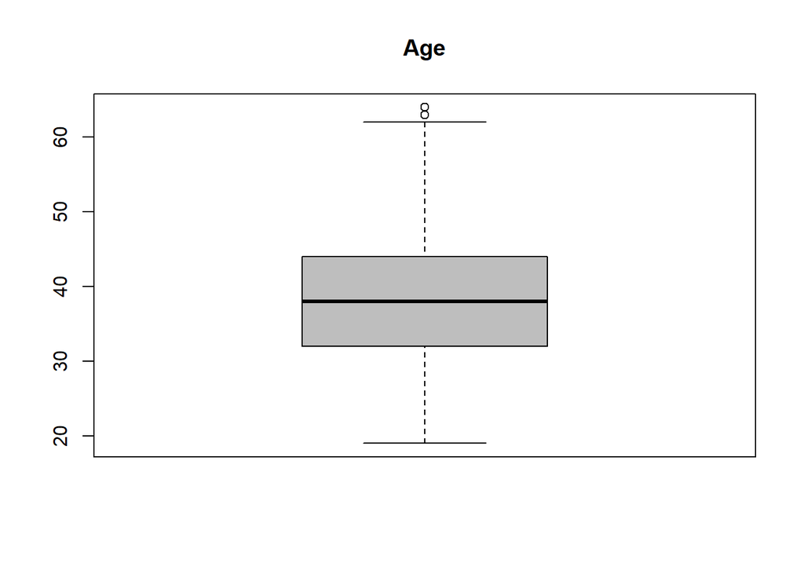

```r
# visualizamos los datos extremos
boxplot(df_claim$age, main="Age",col="gray")
```

### 4. Análisis de los datos.

#### 4.1. Selección de los grupos de datos que se quieren analizar/comparar (planificación de los análisis a aplicar).

- agrupación por sexo (2 niveles)

```r
claim_male <- df_claim %>% filter(df_claim$insured_sex=="MALE")
claim_female <- df_claim %>% filter(df_claim$insured_sex=="FEMALE")
```

*agrupación por fraude (2 niveles)

```r
claim_fraudy <- df_claim %>% filter(df_claim$fraud_reported=="Y")
claim_fraudn <- df_claim %>% filter(df_claim$fraud_reported=="N")
```

Grupo de incidentes: * agrupacion por tipo de incidente (4 niveles)

```r
claim_multi <- df_claim %>% filter(df_claim$incident_type =="Multi-vehicle Collision")
claim_parked <- df_claim %>% filter(df_claim$incident_type =="Parked Car")
claim_single <- df_claim %>% filter(df_claim$incident_type =="Single Vehicle Collision")
claim_theft <- df_claim %>% filter(df_claim$incident_type =="Vehicle Theft")
```

- agrupacion numero de vehiculos implicados (4 niveles)

```r
claim_one <- df_claim %>% filter(df_claim$number_of_vehicles_involved=="1")
claim_two <- df_claim %>% filter(df_claim$number_of_vehicles_involved=="2")
claim_three <- df_claim %>% filter(df_claim$number_of_vehicles_involved=="3")
claim_four <- df_claim %>% filter(df_claim$number_of_vehicles_involved=="4")
```

- agrupacion por tipo de colision (4 niveles)

```r
claim_Front <- df_claim %>% filter(df_claim$collision_type =="Front Collision")
claim_No <- df_claim %>% filter(df_claim$collision_type =="No collision")
claim_Rear <- df_claim %>% filter(df_claim$collision_type =="Rear Collision")
claim_Side <- df_claim %>% filter(df_claim$collision_type =="Side Collision")
```

#### 4.2. Comprobación de la normalidad y homogeneidad de la varianza.

Para comprobar la normalidad instalamos el paquete Nortest que se componen de diferentes pruebas para comprobar la normalidad en los datos. En ete caso utilizaremos la prueba de Lilliefors (Kolmogorov-Smirnov) es una prueba general para la hipótesis compuesta de normalidad con grupo de datos mayor a 30. El estadístico de prueba es la diferencia absoluta máxima entre empírico e hipotético.

```r
res <- sapply(df_claim,class)
res <- which(res=="integer")
# aplicamos el test a las variables las 7 numericas

for (i in res){
  p <- lillie.test(df_claim[,i])
  p$data.name <- colnames(df_claim)[i]
  print(p)
}
```

```
##
##  Lilliefors (Kolmogorov-Smirnov) normality test
##
## data:  months_as_customer
## D = 0.050508, p-value = 2.689e-06
##
##
##  Lilliefors (Kolmogorov-Smirnov) normality test
##
## data:  age
## D = 0.065863, p-value = 5.174e-11
##
##
##  Lilliefors (Kolmogorov-Smirnov) normality test
##
## data:  policy_number
## D = 0.056882, p-value = 4.396e-08
##
##
##  Lilliefors (Kolmogorov-Smirnov) normality test
##
## data:  insured_zip
## D = 0.3228, p-value < 2.2e-16
##
##
##  Lilliefors (Kolmogorov-Smirnov) normality test
##
## data:  incident_hour_of_the_day
## D = 0.083552, p-value < 2.2e-16
##
##
##  Lilliefors (Kolmogorov-Smirnov) normality test
##
## data:  auto_year
## D = 0.081182, p-value < 2.2e-16
```

Como podemos comprobar ninguna variable cumple normalidad.

El supuesto de homogeneidad de varianzas, también conocido como supuesto de homocedasticidad, considera que la varianza es constante en los diferentes niveles de un factor, es decir, entre diferentes grupos. Prodecemos a revisar la homogeniedad de la varianza usando el test de Levene. El test de Levene se puede aplicar con la función leveneTest() del paquete car. Se caracteriza, además de por poder comparar 2 o más poblaciones, por permitir elegir entre diferentes estadísticos de centralidad :mediana (por defecto), media, media truncada. Esto es importante a la hora de contrastar la homocedasticidad dependiendo de si los grupos se distribuyen de forma normal o no.

```r
leveneTest(y = as.integer(df_claim$fraud_reported), group = df_claim$insured_sex, center = "median")
```

```
## Levene's Test for Homogeneity of Variance (center = "median")
##        Df F value Pr(>F)
## group   1  0.9521 0.3294
##       998
```

Puesto que obtenemos un p-valor superior a 0,05, aceptamos la hipótesis de que las varianzas de ambas muestras son homogéneas.

### 4.3. Aplicación de pruebas estadísticas para comparar los grupos de datos. En función de los datos y el objetivo del estudio, aplicar pruebas de contraste de hipótesis, correlaciones, regresiones, etc.

Para encontrar la correlacion entre todas las variables de datos seleccionados realizaremos una transformación a numericas ya que la correlación trabaja solamente con valores numericos. Utilizaremos el paquete “carret” para crear variables dummys y convertir las variables categoricas a numericas.

```r
# se transforman las variables
dmy <- dummyVars(" ~ .", data = df_claim)
claimstrns <- data.frame(predict(dmy, newdata = df_claim))
# usamos dos funciones para crear la matix de correlacion
cor.prob <- function (X, dfr = nrow(X) - 2) {
  R <- cor(X, use="pairwise.complete.obs")
  above <- row(R) < col(R)
  r2 <- R[above]^2
  Fstat <- r2 * dfr/(1 - r2)
  R[above] <- 1 - pf(Fstat, 1, dfr)
  R[row(R) == col(R)] <- NA
  R
}

flattenSquareMatrix <- function(m) {
  if( (class(m) != "matrix") | (nrow(m) != ncol(m))) stop("Must be a square matrix.")
  if(!identical(rownames(m), colnames(m))) stop("Row and column names must be equal.")
  ut <- upper.tri(m)
  data.frame(i = rownames(m)[row(m)[ut]],
             j = rownames(m)[col(m)[ut]],
             cor=t(m)[ut],
             p=m[ut])
}
# representamos las correlaciones
corMasterList <- flattenSquareMatrix (cor.prob(claimstrns))
print(head(corMasterList,10))
```

```
##                     i                j           cor          p
## 1  months_as_customer              age  0.9220983226 0.00000000
## 2  months_as_customer    policy_number  0.0575550330 0.06886845
## 3                 age    policy_number  0.0594134783 0.06036358
## 4  months_as_customer policy_bind_date -0.0481727485 0.12792525
## 5                 age policy_bind_date -0.0369407214 0.24316777
## 6       policy_number policy_bind_date -0.0401042604 0.20510821
## 7  months_as_customer      insured_zip  0.0178947610 0.57192446
## 8                 age      insured_zip  0.0256041758 0.41863305
## 9       policy_number      insured_zip  0.0070832059 0.82298040
## 10   policy_bind_date      insured_zip -0.0002101377 0.99470462
```

```r
corList <- corMasterList[order(corMasterList$cor),]
kable(head(corList,10))
```

|  | i | j | cor | p |
| --- | --- | --- | --- | --- |
| 21 | insured_sex.FEMALE | insured_sex.MALE | -1.0000000 | 0 |
| 1746 | incident_type.Multi.vehicle.Collision | number_of_vehicles_involved.1 | -1.0000000 | 0 |
| 388521 | fraud_reported.N | fraud_reported.Y | -1.0000000 | 0 |
| 1890 | number_of_vehicles_involved.1 | number_of_vehicles_involved.3 | -0.8793364 | 0 |
| 665 | incident_type.Multi.vehicle.Collision | incident_type.Single.Vehicle.Collision | -0.6977250 | 0 |
| 1867 | incident_type.Single.Vehicle.Collision | number_of_vehicles_involved.3 | -0.6135350 | 0 |
| 387682 | incident_severity.L | fraud_reported.Y | -0.4059877 | 0 |
| 386803 | incident_severity.Q | fraud_reported.N | -0.3975927 | 0 |
| 903 | incident_severity.L | incident_severity.Q | -0.3610341 | 0 |
| 1174 | incident_state.NY | incident_state.SC | -0.3421680 | 0 |

```r
# seleccionamos las variables que nos interesan

df_reg <- df %>% select("fraud_reported","insured_sex","collision_type","incident_type","number_of_vehicles_involved")
dmy <- dummyVars(" ~ .", data = df_reg)
claimreg <- data.frame(predict(dmy, newdata = df_reg))

# Aplicamos el modelo de regresion
model <- (lm(formula = fraud_reportedY  ~ insured_sexMALE + collision_type. + number_of_vehicles_involved + incident_typeMulti.vehicle.Collision + incident_typeParked.Car, data = claimreg))
summary (model)
```

```
##
## Call:
## lm(formula = fraud_reportedY ~ insured_sexMALE + collision_type. +
##     number_of_vehicles_involved + incident_typeMulti.vehicle.Collision +
##     incident_typeParked.Car, data = claimreg)
##
## Residuals:
##      Min       1Q   Median       3Q      Max
## -0.31334 -0.28768 -0.25825 -0.06945  0.93055
##
## Coefficients:
##                                      Estimate Std. Error t value Pr(>|t|)
## (Intercept)                           0.25145    0.05931   4.239 2.45e-05
## insured_sexMALE                       0.02943    0.02707   1.087    0.277
## collision_type.                      -0.20765    0.04884  -4.252 2.32e-05
## number_of_vehicles_involved           0.02566    0.05459   0.470    0.638
## incident_typeMulti.vehicle.Collision -0.07017    0.11325  -0.620    0.536
## incident_typeParked.Car               0.01317    0.06401   0.206    0.837
##
## (Intercept)                          ***
## insured_sexMALE
## collision_type.                      ***
## number_of_vehicles_involved
## incident_typeMulti.vehicle.Collision
## incident_typeParked.Car
## ---
## Signif. codes:  0 '***' 0.001 '**' 0.01 '*' 0.05 '.' 0.1 ' ' 1
##
## Residual standard error: 0.4259 on 994 degrees of freedom
## Multiple R-squared:  0.03055,    Adjusted R-squared:  0.02567
## F-statistic: 6.264 on 5 and 994 DF,  p-value: 9.875e-06
```

El resultado indica que el modelo de regresión múltiple explica tan solo el 3% de la variabilidad de clasificar un accidente como fraudulento. No parece ser un modelo acertado. Por ello debemos volver a evaluar si el conjunto de datos es el adecuado. Evaluando el modelo obtenido con la funcion “step”.

```r
step(object = model, direction = "both", trace = 1)
```

```
## Start:  AIC=-1701.08
## fraud_reportedY ~ insured_sexMALE + collision_type. + number_of_vehicles_involved +
##     incident_typeMulti.vehicle.Collision + incident_typeParked.Car
##
##                                        Df Sum of Sq    RSS     AIC
## - incident_typeParked.Car               1    0.0077 180.32 -1703.0
## - number_of_vehicles_involved           1    0.0401 180.35 -1702.9
## - incident_typeMulti.vehicle.Collision  1    0.0696 180.38 -1702.7
## - insured_sexMALE                       1    0.2144 180.52 -1701.9
## <none>                                              180.31 -1701.1
## - collision_type.                       1    3.2797 183.59 -1685.0
##
## Step:  AIC=-1703.04
## fraud_reportedY ~ insured_sexMALE + collision_type. + number_of_vehicles_involved +
##     incident_typeMulti.vehicle.Collision
##
##                                        Df Sum of Sq    RSS     AIC
## - number_of_vehicles_involved           1    0.0401 180.36 -1704.8
## - incident_typeMulti.vehicle.Collision  1    0.0697 180.39 -1704.7
## - insured_sexMALE                       1    0.2112 180.53 -1703.9
## <none>                                              180.32 -1703.0
## + incident_typeParked.Car               1    0.0077 180.31 -1701.1
## - collision_type.                       1    5.0065 185.32 -1677.7
##
## Step:  AIC=-1704.82
## fraud_reportedY ~ insured_sexMALE + collision_type. + incident_typeMulti.vehicle.Collision
##
##                                        Df Sum of Sq    RSS     AIC
## - incident_typeMulti.vehicle.Collision  1    0.0726 180.43 -1706.4
## - insured_sexMALE                       1    0.2200 180.58 -1705.6
## <none>                                              180.36 -1704.8
## + number_of_vehicles_involved           1    0.0401 180.32 -1703.0
## + incident_typeParked.Car               1    0.0078 180.35 -1702.9
## - collision_type.                       1    5.0075 185.37 -1679.4
##
## Step:  AIC=-1706.41
## fraud_reportedY ~ insured_sexMALE + collision_type.
##
##                                        Df Sum of Sq    RSS     AIC
## - insured_sexMALE                       1    0.2158 180.65 -1707.2
## <none>                                              180.43 -1706.4
## + incident_typeMulti.vehicle.Collision  1    0.0726 180.36 -1704.8
## + number_of_vehicles_involved           1    0.0430 180.39 -1704.7
## + incident_typeParked.Car               1    0.0077 180.42 -1704.5
## - collision_type.                       1    5.3838 185.81 -1679.0
##
## Step:  AIC=-1707.22
## fraud_reportedY ~ collision_type.
##
##                                        Df Sum of Sq    RSS     AIC
## <none>                                              180.65 -1707.2
## + insured_sexMALE                       1    0.2158 180.43 -1706.4
## + incident_typeMulti.vehicle.Collision  1    0.0684 180.58 -1705.6
## + number_of_vehicles_involved           1    0.0377 180.61 -1705.4
## + incident_typeParked.Car               1    0.0046 180.64 -1705.2
## - collision_type.                       1    5.3453 185.99 -1680.1
```

```
##
## Call:
## lm(formula = fraud_reportedY ~ collision_type., data = claimreg)
##
## Coefficients:
##     (Intercept)  collision_type.
##          0.2810          -0.1911
```

```r
df_claim$fraud_reported <- if_else(df_claim$fraud_reported=="Y", 1, 0)
t.test(df_claim$fraud_reported, mu=TRUE, alternative = "less")
```

```
##
##  One Sample t-test
##
## data:  df_claim$fraud_reported
## t = -55.186, df = 999, p-value < 2.2e-16
## alternative hypothesis: true mean is less than TRUE
## 95 percent confidence interval:
##       -Inf 0.2694643
## sample estimates:
## mean of x
##     0.247
```

### 5. Representación de los resultados a partir de tablas y gráficas.

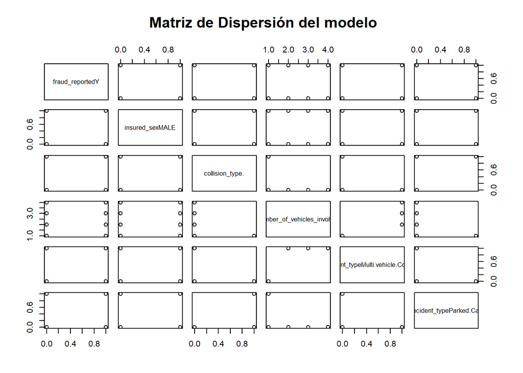

```r
# representacion grafica
pairs(fraud_reportedY  ~ insured_sexMALE + collision_type. + number_of_vehicles_involved + incident_typeMulti.vehicle.Collision + incident_typeParked.Car, data = claimreg, main=" Matriz de Dispersión del modelo")
```

###6.Resolución del problema. A partir de los resultados obtenidos, ¿cuáles son las conclusiones? ¿Los resultados permiten responder al problema?

Las conclusiones obtenidas nos indican que debemos revisar desde las variables seleccionadas a los modelos aplicados. Los resultados no han sido nada concluyentes y no se ha podido responder con claridad a las cuestiones planteadas.